# Lab 15: Transformations

Tyler Scott

2015-08-16

## Goals for Today

1. Perform (and understand) basic transformations
2. Compare transformed and untransformed models
3. Gain intuition about why/when to transform
4. Standardize and interpret standardized variables

For today’s lab, we will use the dataset of Michael Ross, “Does Oil Hinder Democracy?” *World Politics*, 2001. That paper estimated a time series cross-section model of Polity scores regressed on oil exports and a battery of controls.

```r
library("dplyr")
library("ggplot2")
rossdata_url <- "http://staff.washington.edu/csjohns/503/rossoildata.csv"
rossdata_raw <- read.csv(rossdata_url, stringsAsFactors = FALSE)
rossdata <- rossdata_raw %>%
  select(cty_name, year, regime1, oil, GDPcap, oecd) %>%
  na.omit()
```

```r
model1 <- lm(regime1 ~ GDPcap + oil + oecd + year, data = rossdata)
summary(model1)
```

```
##
## Call:
## lm(formula = regime1 ~ GDPcap + oil + oecd + year, data = rossdata)
##
## Residuals:
##     Min      1Q  Median      3Q     Max
## -7.8284 -2.5065 -0.2086  2.2014  8.0464
##
## Coefficients:
##               Estimate Std. Error t value Pr(>|t|)
## (Intercept) -1.736e+02  1.664e+01 -10.433  < 2e-16 ***
## GDPcap       6.177e-05  1.823e-05   3.387 0.000716 ***
## oil         -8.262e-02  5.022e-03 -16.450  < 2e-16 ***
## oecd         4.116e+00  1.928e-01  21.346  < 2e-16 ***
## year         9.008e-02  8.413e-03  10.708  < 2e-16 ***
## ---
## Signif. codes:  0 '***' 0.001 '**' 0.01 '*' 0.05 '.' 0.1 ' ' 1
##
## Residual standard error: 2.932 on 2589 degrees of freedom
## Multiple R-squared:  0.4285, Adjusted R-squared:  0.4276
## F-statistic: 485.2 on 4 and 2589 DF,  p-value: < 2.2e-16
```

2. Now predict the expected value of regime type vs. oil, for non-OECD countries with mean GDP per-capita and median year.

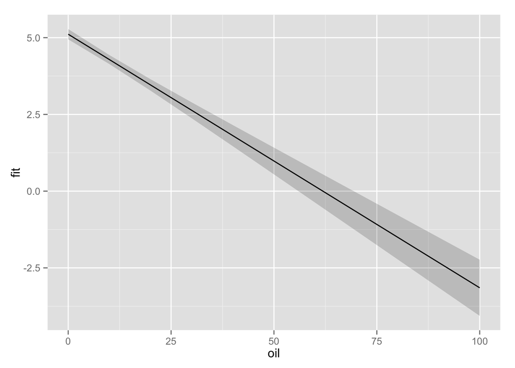

```r
pred1_df <- data.frame(oil = seq(0, 100, by = 10),
                       GDPcap = mean(rossdata$GDPcap),
                       oecd = 0,
                       year = median(rossdata$year))
pred1 <- predict(model1, newdata = pred1_df, interval = "confidence")

ggplot(bind_cols(pred1_df, as.data.frame(pred1)),
       aes(x = oil, y = fit, ymin = lwr, ymax = upr)) +
  geom_ribbon(alpha = 0.2) +
  geom_line()
```

3. Now, repeat this with both OECD and non-OECD countries. Before plotting, how will these differ?

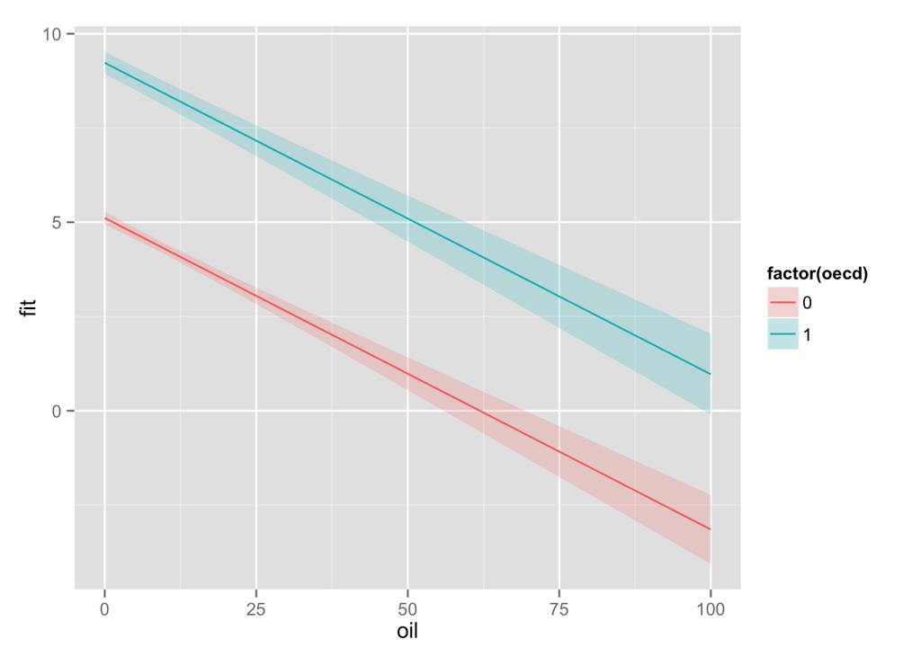

```r
pred2_df <- expand.grid(oil = seq(0, 100, by = 10),
                        GDPcap = mean(rossdata$GDPcap),
                        oecd = c(0, 1),
                        year = median(rossdata$year))
pred2 <- predict(model1, newdata = pred2_df, interval = "confidence")
ggplot(bind_cols(pred2_df, as.data.frame(pred2)),
       aes(x = oil, y = fit, ymin = lwr, ymax = upr,
           colour = factor(oecd), fill = factor(oecd))) +
  geom_ribbon(alpha = 0.2, colour = NA) +
  geom_line()
```

4. Does it make sense to plot `oil` from 0 to 100? Check the range of `oil`.

Surprisingly, not that bad.

```r
summary(rossdata$oil)
```

```
##      Min.   1st Qu.    Median      Mean   3rd Qu.      Max.
##   0.00000   0.05543   0.38110   4.79800   2.17800 115.60000
```

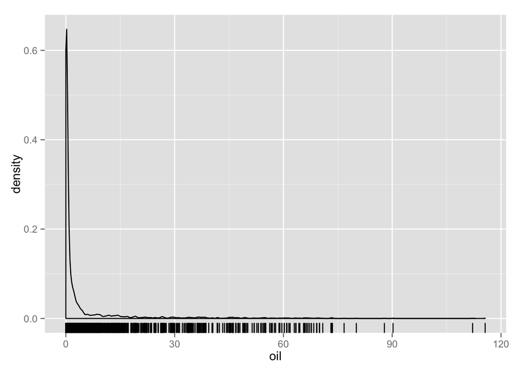

```r
ggplot(rossdata, aes(x = oil)) + geom_density() + geom_rug()
```

5. Interact `oil` with `oecd` and plot (keeping `GDPcap` at the mean, and `year` at the median. What will the lines look like?

```r
model2 <- lm(regime1 ~ GDPcap + oil * oecd + year, data = rossdata)
summary(model2)
```

```
##
## Call:
## lm(formula = regime1 ~ GDPcap + oil * oecd + year, data = rossdata)
##
## Residuals:
##     Min      1Q  Median      3Q     Max
## -7.7411 -2.5075 -0.1755  2.2446  8.0701
##
## Coefficients:
##               Estimate Std. Error t value Pr(>|t|)
## (Intercept) -1.732e+02  1.663e+01 -10.410  < 2e-16 ***
## GDPcap       5.931e-05  1.826e-05   3.248  0.00118 **
## oil         -8.344e-02  5.035e-03 -16.571  < 2e-16 ***
## oecd         4.005e+00  2.003e-01  19.998  < 2e-16 ***
## year         8.985e-02  8.408e-03  10.686  < 2e-16 ***
## oil:oecd     8.863e-02  4.340e-02   2.042  0.04124 *
## ---
## Signif. codes:  0 '***' 0.001 '**' 0.01 '*' 0.05 '.' 0.1 ' ' 1
##
## Residual standard error: 2.93 on 2588 degrees of freedom
## Multiple R-squared:  0.4294, Adjusted R-squared:  0.4283
## F-statistic: 389.5 on 5 and 2588 DF,  p-value: < 2.2e-16
```

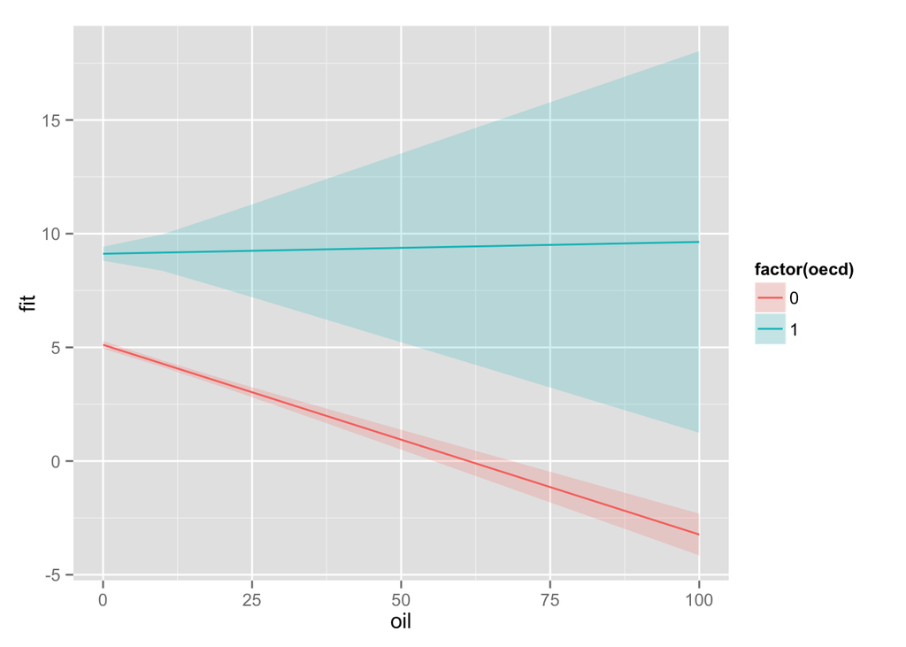

```r
pred.mod2_df <- expand.grid(oil = seq(0, 100, by = 10),
                        GDPcap = mean(rossdata$GDPcap),
                        oecd = c(0, 1),
                        year = median(rossdata$year))
pred.mod2 <- predict(model2, newdata = pred.mod2_df, interval = "confidence")
ggplot(bind_cols(pred.mod2_df, as.data.frame(pred.mod2)),
       aes(x = oil, y = fit, ymin = lwr, ymax = upr,
           colour = factor(oecd), fill = factor(oecd))) +
  geom_ribbon(alpha = 0.2, colour = NA) +
  geom_line()
```

6. Now consider the interaction of `oil` with `year`. How would you plot two continuous variables?

```r
model3 <- lm(regime1 ~ GDPcap + oecd + oil * year, data = rossdata)
summary(model3)
```

```
##
## Call:
## lm(formula = regime1 ~ GDPcap + oecd + oil * year, data = rossdata)
##
## Residuals:
##     Min      1Q  Median      3Q     Max
## -7.7659 -2.4662 -0.2211  2.2458  7.5283
##
## Coefficients:
##               Estimate Std. Error t value Pr(>|t|)
## (Intercept) -1.900e+02  1.721e+01 -11.039  < 2e-16 ***
## GDPcap       6.228e-05  1.819e-05   3.424 0.000628 ***
## oecd         4.108e+00  1.924e-01  21.351  < 2e-16 ***
## oil          4.400e+00  1.242e+00   3.543 0.000403 ***
## year         9.835e-02  8.700e-03  11.304  < 2e-16 ***
## oil:year    -2.263e-03  6.269e-04  -3.609 0.000313 ***
## ---
## Signif. codes:  0 '***' 0.001 '**' 0.01 '*' 0.05 '.' 0.1 ' ' 1
##
## Residual standard error: 2.925 on 2588 degrees of freedom
## Multiple R-squared:  0.4313, Adjusted R-squared:  0.4302
## F-statistic: 392.6 on 5 and 2588 DF,  p-value: < 2.2e-16
```

In order to interpret the interaction term graphically, we need to pick one variable to treat as continuous — the x-axis — and another for which we will choose specific values. Use `oil` as the x-axis, and some values of `year` at which to evaluate it. For `year` we could use the min, max, and median.

```r
pred3_newdata <- expand.grid(oecd = 0,
                             GDPcap = mean(rossdata$GDPcap),
                             year = c(1966, 1981, 1997),
                             oil = seq(0, 100, by = 10))
pred3 <- predict(model3, newdata = pred3_newdata, interval = "confidence")
pred3 <- cbind(pred3,pred3_newdata)
```

Now, let’s plot it,

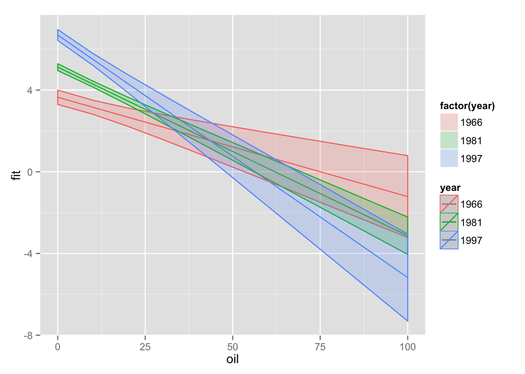

```r
ggplot(pred3, aes(x = oil, y = fit,
                  ymin = lwr,
                  ymax = upr,
                  colour = factor(year),fill=factor(year))) +
  geom_line() + geom_ribbon(alpha=0.2) +
  scale_colour_discrete("year")
```

## First Differences

```r
year_seq <- seq(min(rossdata$year), max(rossdata$year), by = 1)
oil_lo <- mean(rossdata$oil)
oil_hi <- mean(rossdata$oil) + sd(rossdata$oil)
pred3_oil_lo <-
  predict(model3,
          newdata = data.frame(year = year_seq,
                               GDPcap = mean(rossdata$GDPcap),
                               oil = oil_lo,
                               oecd = 0),
          interval = "confidence")

pred3_oil_hi <-
  predict(model3,
          newdata = data.frame(year = year_seq,
                               GDPcap = mean(rossdata$GDPcap),
                               oil = oil_hi,
                               oecd = 0),
          interval = "confidence")
```

The first difference is calculated. Note that there are no standard error associated with these differences.

```r
pred3_diff <- data.frame(year = year_seq,
                         diff = pred3_oil_hi[ , "fit"] - pred3_oil_lo[ , "fit"])
head(pred3_diff)
```

```
##   year       diff
## 1 1966 -0.5999518
## 2 1967 -0.6278718
## 3 1968 -0.6557918
## 4 1969 -0.6837118
## 5 1970 -0.7116318
## 6 1971 -0.7395518
```

We could plot these differences over time.

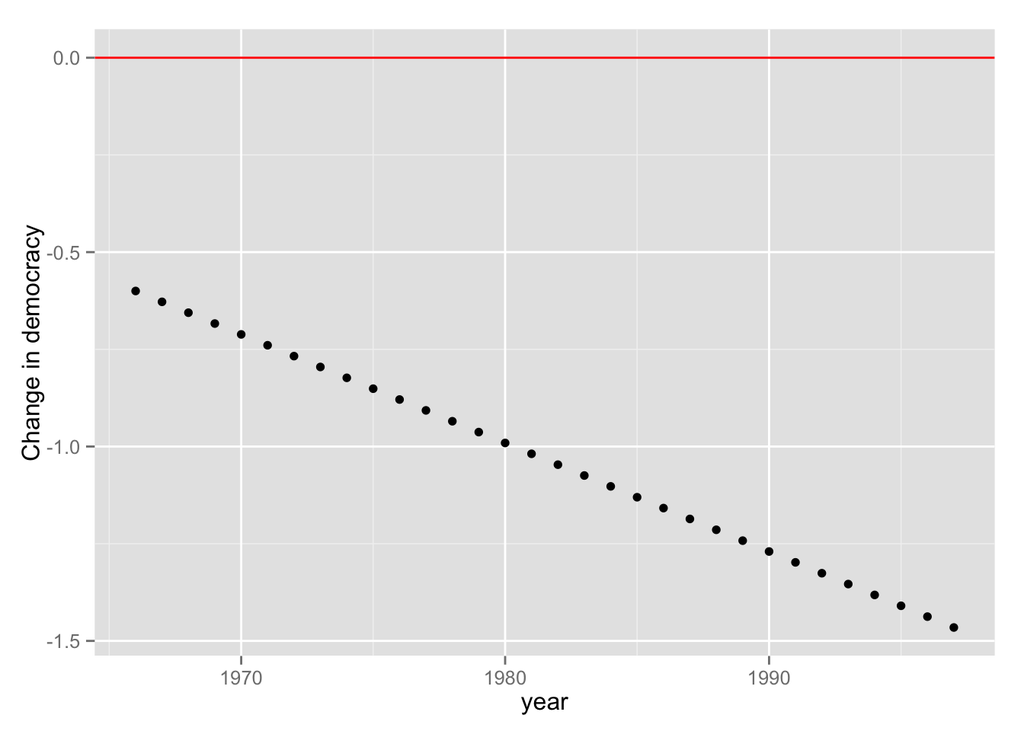

```r
ggplot(pred3_diff, aes(x = year, y = diff)) +
  geom_point() +
  geom_hline(yintercept = 0, colour = "red") +
  scale_y_continuous("Change in democracy")
```

# Transformations

What if we suspect the effect of oil is non-linear?

Specifying a model:

```r
model4 <- lm(regime1 ~ GDPcap + oil + I(oil^2) + oecd, data = rossdata)
summary(model4)
```

```
##
## Call:
## lm(formula = regime1 ~ GDPcap + oil + I(oil^2) + oecd, data = rossdata)
##
## Residuals:
##     Min      1Q  Median      3Q     Max
## -7.6194 -2.7171 -0.1169  2.1843  7.8092
##
## Coefficients:
##               Estimate Std. Error t value Pr(>|t|)
## (Intercept)  4.593e+00  8.301e-02  55.329   <2e-16 ***
## GDPcap       1.878e-04  1.425e-05  13.180   <2e-16 ***
## oil         -1.084e-01  1.213e-02  -8.935   <2e-16 ***
## I(oil^2)     2.691e-04  1.941e-04   1.387    0.166
## oecd         3.171e+00  1.759e-01  18.034   <2e-16 ***
## ---
## Signif. codes:  0 '***' 0.001 '**' 0.01 '*' 0.05 '.' 0.1 ' ' 1
##
## Residual standard error: 2.995 on 2589 degrees of freedom
## Multiple R-squared:  0.4036, Adjusted R-squared:  0.4027
## F-statistic:   438 on 4 and 2589 DF,  p-value: < 2.2e-16
```

```r
oil_hyp <- seq(from = 0.01, to = 100, by = 10)
pred4 <- predict(model4,
                 newdata = data.frame(oil = oil_hyp,
                                      GDPcap = mean(rossdata$GDPcap),
                                      oecd = 0),
                 interval = "confidence") %>%
  as.data.frame()
pred4$oil <- oil_hyp
```

Plotting the resulting expectations:

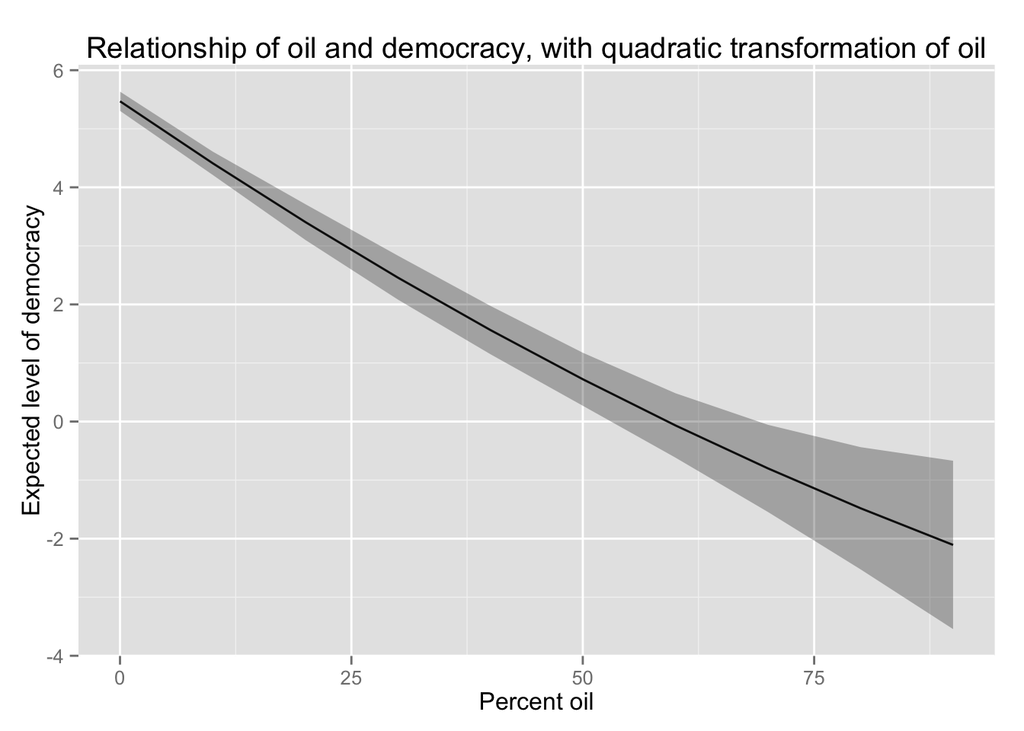

```r
ggplot(pred4, aes(x = oil)) +
  geom_line(aes(y = fit)) +
  geom_ribbon(aes(ymax = upr, ymin = lwr), alpha = 1/3) +
  labs(x = "Percent oil", y = "Expected level of democracy", title = "Relationship of oil and democracy, with quadratic transformation of oil")
```

7. Transform GDP per capita by log and refit the model

```r
model_logGDP <- lm(regime1 ~ log(GDPcap) + oil + oecd, data = rossdata)
summary(model_logGDP)
```

```
##
## Call:
## lm(formula = regime1 ~ log(GDPcap) + oil + oecd, data = rossdata)
##
## Residuals:
##    Min     1Q Median     3Q    Max
## -7.169 -2.125 -0.077  2.010  7.539
##
## Coefficients:
##             Estimate Std. Error t value Pr(>|t|)
## (Intercept) -5.46656    0.42426  -12.88   <2e-16 ***
## log(GDPcap)  1.43853    0.05761   24.97   <2e-16 ***
## oil         -0.11005    0.00470  -23.42   <2e-16 ***
## oecd         2.22692    0.15951   13.96   <2e-16 ***
## ---
## Signif. codes:  0 '***' 0.001 '**' 0.01 '*' 0.05 '.' 0.1 ' ' 1
##
## Residual standard error: 2.778 on 2590 degrees of freedom
## Multiple R-squared:  0.4868, Adjusted R-squared:  0.4862
## F-statistic: 818.8 on 3 and 2590 DF,  p-value: < 2.2e-16
```

```r
gdp_hyp <- seq(from = min(rossdata$GDPcap), to = max(rossdata$GDPcap), length.out = 50)
pred.logGDP <- predict(model_logGDP,
newdata = data.frame(oil = median(oil_hyp),
                                      GDPcap = gdp_hyp,
                                      oecd = 0),
                 interval = "confidence") %>%
  as.data.frame()
pred.logGDP$gdp <- gdp_hyp
```

8. Why was median used there?

9. Plot the resulting expectations:

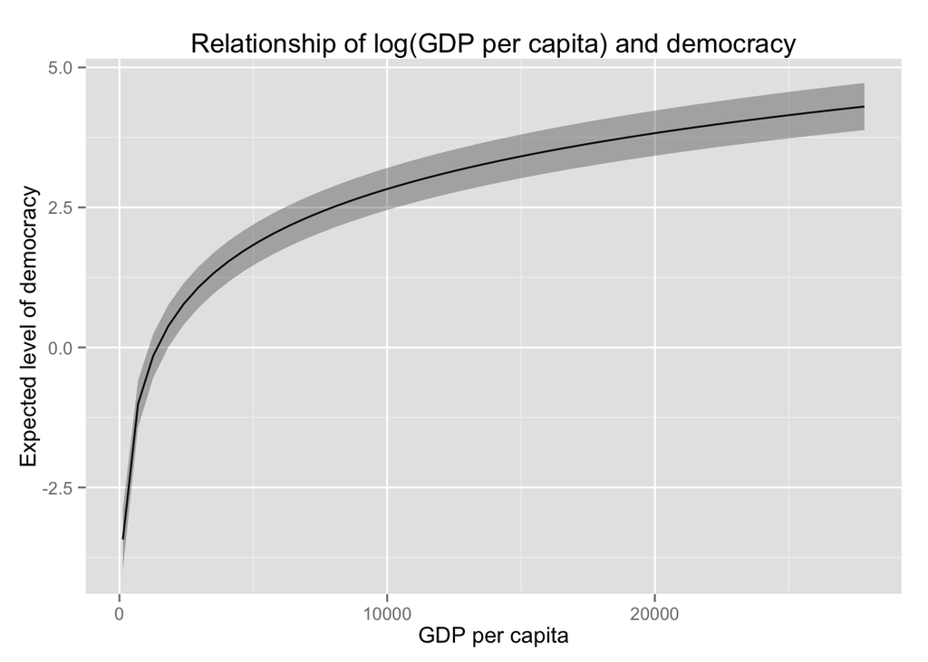

```r
ggplot(pred.logGDP, aes(x = gdp)) +
  geom_line(aes(y = fit)) +
  geom_ribbon(aes(ymax = upr, ymin = lwr), alpha = 1/3) +
  labs(x = "GDP per capita", y = "Expected level of democracy", title = "Relationship of log(GDP per capita) and democracy")
```

10. Transform oil by log. What happens? How would you solve it?

```r
library(magrittr)
rossdata %>% mutate(l.oil = log(oil)) %>% summary(.$l.oil)
```

```
##    cty_name              year         regime1            oil
##  Length:2594        Min.   :1966   Min.   : 0.000   Min.   :  0.00000
##  Class :character   1st Qu.:1974   1st Qu.: 1.500   1st Qu.:  0.05543
##  Mode  :character   Median :1981   Median : 6.500   Median :  0.38108
##                     Mean   :1981   Mean   : 5.794   Mean   :  4.79830
##                     3rd Qu.:1989   3rd Qu.:10.000   3rd Qu.:  2.17798
##                     Max.   :1997   Max.   :10.000   Max.   :115.63168
##      GDPcap             oecd            l.oil
##  Min.   :  129.0   Min.   :0.0000   Min.   :-Inf
##  1st Qu.:  962.5   1st Qu.:0.0000   1st Qu.:  -3
##  Median : 2588.0   Median :0.0000   Median :  -1
##  Mean   : 4672.4   Mean   :0.2513   Mean   :-Inf
##  3rd Qu.: 6136.2   3rd Qu.:1.0000   3rd Qu.:   1
##  Max.   :27826.8   Max.   :1.0000   Max.   :   5
```

Log of 0 is undefined. This is often handled by adding and arbitrary small value to 0’s. In this case we’ll add 0.001. There are better ways to deal with this, but for now…

```r
model5 <- lm(regime1 ~ GDPcap + log(oil_mod) + oecd,
             data = mutate(rossdata, oil_mod = log(oil + 0.001)))
summary(model5)
```

```
##
## Call:
## lm(formula = regime1 ~ GDPcap + log(oil_mod) + oecd, data = mutate(rossdata,
##     oil_mod = log(oil + 0.001)))
##
## Residuals:
##      Min       1Q   Median       3Q      Max
## -10.6337  -2.4525  -0.7552   1.2146   6.5659
##
## Coefficients:
##                Estimate Std. Error t value Pr(>|t|)
## (Intercept)   3.850e+00  1.434e-01  26.847  < 2e-16 ***
## GDPcap        2.708e-05  2.419e-05   1.119    0.263
## log(oil_mod) -7.896e-01  1.018e-01  -7.755 2.42e-14 ***
## oecd          5.420e+00  3.310e-01  16.373  < 2e-16 ***
## ---
## Signif. codes:  0 '***' 0.001 '**' 0.01 '*' 0.05 '.' 0.1 ' ' 1
##
## Residual standard error: 2.976 on 887 degrees of freedom
##   (1703 observations deleted due to missingness)
## Multiple R-squared:  0.4523, Adjusted R-squared:  0.4504
## F-statistic: 244.1 on 3 and 887 DF,  p-value: < 2.2e-16
```

```r
pred5 <- predict(model5,
                 newdata = data.frame(oil_mod = seq(from = 0.01, to = 100, by = 10),
                                      GDPcap = mean(rossdata$GDPcap),
                                      oecd = 0),
                 interval = "confidence")
```

# Post-estimation Diagnostics

Recall the default model,

```r
model1
```

```
##
## Call:
## lm(formula = regime1 ~ GDPcap + oil + oecd + year, data = rossdata)
##
## Coefficients:
## (Intercept)       GDPcap          oil         oecd         year
##  -1.736e+02    6.177e-05   -8.262e-02    4.116e+00    9.008e-02
```

Extract residuals and fitted values from an `lm` object:

```r
result.vals = data.frame(residuals = model1$residuals,fitted = model1$fitted.values,outcome = rossdata$regime1,std.resids = rstandard(model1))
```

11. Plot the fitted values vs. the outcome variable to look for nonlinearity,

```
## geom_smooth: method="auto" and size of largest group is >=1000, so using gam with formula: y ~ s(x, bs = "cs"). Use 'method = x' to change the smoothing method.
```

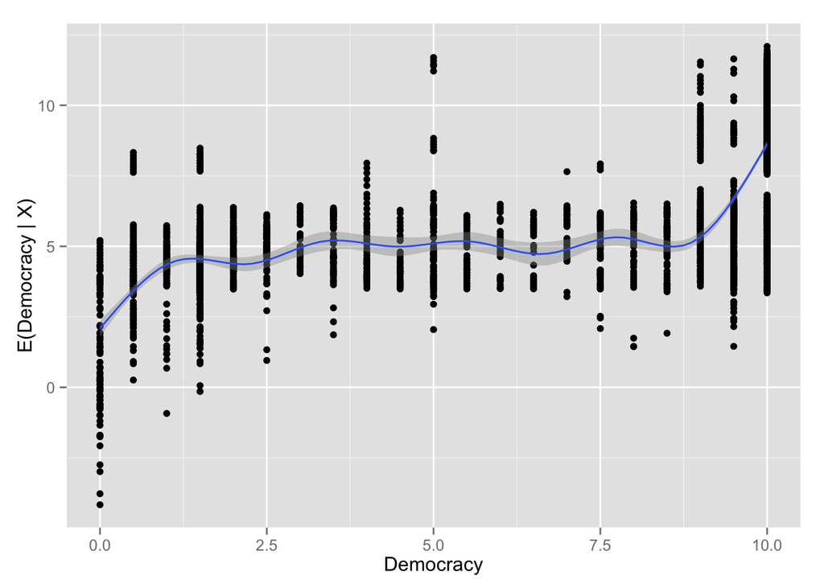

```r
ggplot(result.vals, aes(y = fitted,x = outcome)) +
  geom_point() +
  geom_smooth() +
  ylab("E(Democracy | X)") +
  xlab("Democracy")
```

and the residuals vs. the fitted values to look for heteroskedasticity

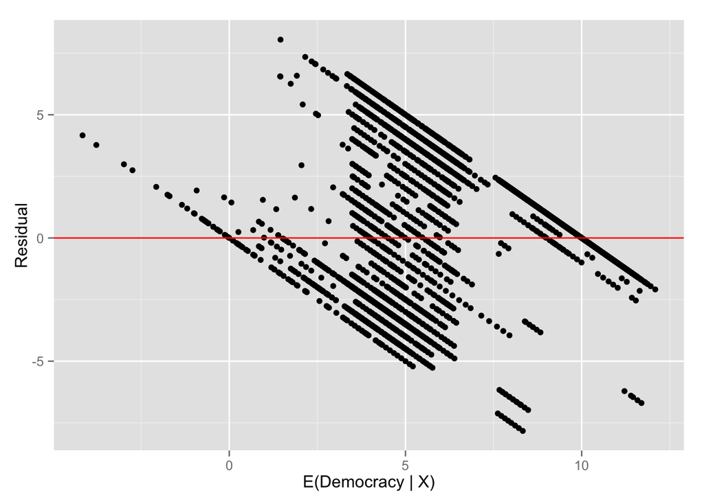

```r
ggplot(result.vals, aes(x = fitted, y = residuals)) +
  geom_point() +
  geom_hline(yintercept = 0, colour = "red") +
  ylab("Residual") +
  xlab("E(Democracy | X)")
```

12. What accounts for the unusual patterns? *hint:* What values can Democracy take?

```r
table(rossdata$regime1)
```

```
##
##   0 0.5   1 1.5   2 2.5   3 3.5   4 4.5   5 5.5   6 6.5   7 7.5   8 8.5
##  91 211  76 410  80  68  32  53  50  34  92  51  27  28  28  65  48  56
##   9 9.5  10
## 197 204 693
```

It is obvious in this case, but plotting the sqrt of the absolute value of the standardized residuals errors can make it more clear

```
## geom_smooth: method="auto" and size of largest group is >=1000, so using gam with formula: y ~ s(x, bs = "cs"). Use 'method = x' to change the smoothing method.
```

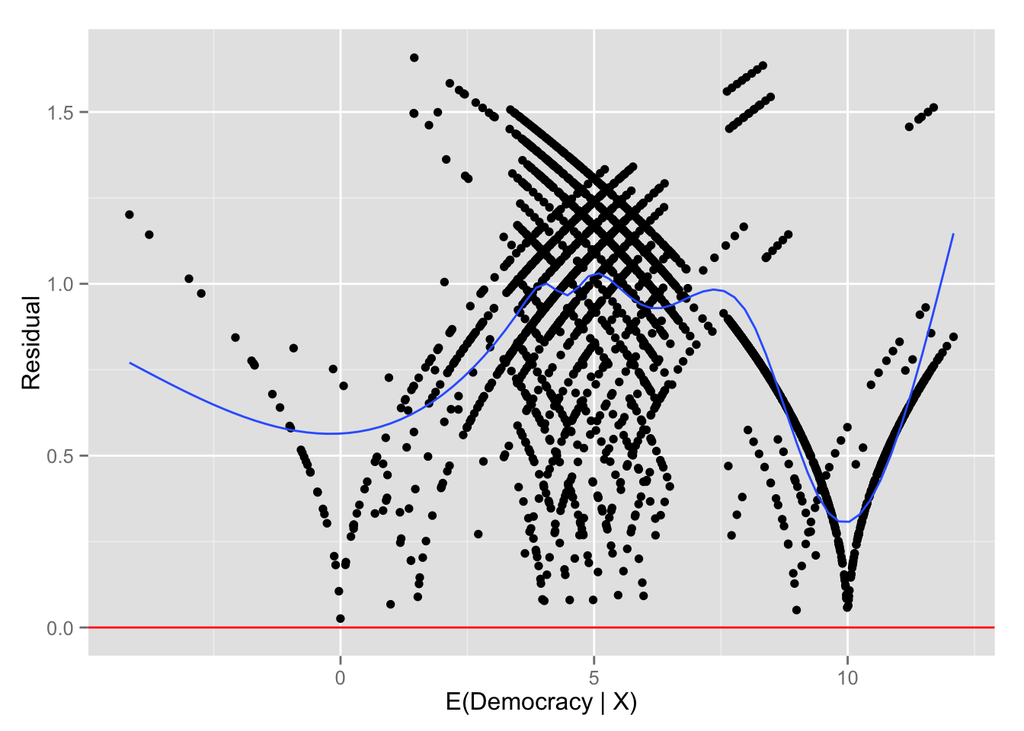

```r
  ggplot(result.vals, aes(x = fitted, y = sqrt(abs(std.resids)))) +
#ggplot(model1_aug, aes(x = .fitted, y = sqrt(abs(.std.resid)))) +
  geom_point() +
  geom_hline(yintercept = 0, colour = "red") +
  geom_smooth(se = FALSE) +
  ylab("Residual") +
  xlab("E(Democracy | X)")
```

13. For model 1, plot residuals against each independent variable and the fitted values. Is there evidence of heteroskedasticity or nonlinearity?

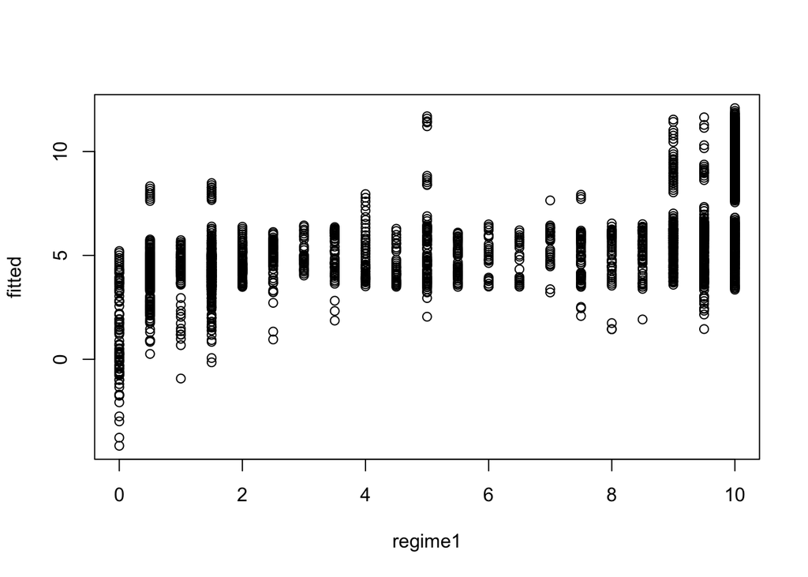

```r
results = data.frame(residuals = model1$residuals,fitted = model1$fitted.values,std.resids = rstandard(model1),rossdata)
plot(fitted~regime1,results)
```

Eh, doesn’t look super bad, but not great either.

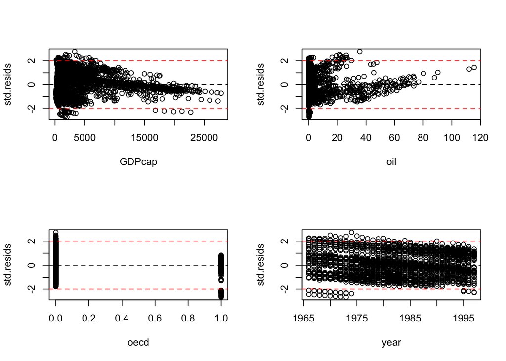

```r
par(mfrow=c(2,2))
plot(std.resids~GDPcap,results)
abline(h=2,lty=2,col='red');abline(h=-2,lty=2,col='red');abline(h=0,lty=2)
plot(std.resids~oil,results)
abline(h=2,lty=2,col='red');abline(h=-2,lty=2,col='red');abline(h=0,lty=2)
plot(std.resids~oecd,results)
abline(h=2,lty=2,col='red');abline(h=-2,lty=2,col='red');abline(h=0,lty=2)
plot(std.resids~year,results)
abline(h=2,lty=2,col='red');abline(h=-2,lty=2,col='red');abline(h=0,lty=2)
```

```r
par(mfrow=c(1,1))
```

Definitely heteroskedasticity, with regards to both GDP per-capita and oil (in both cases, high variance at low levels and low variance at high levels)

14. What about the normality of errors?

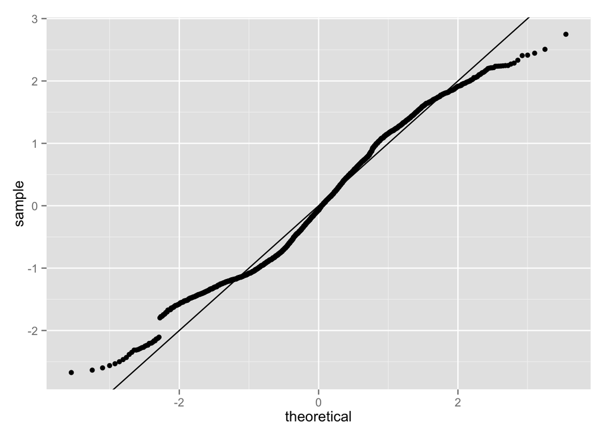

```r
ggplot(results, aes(sample = std.resids)) +
  stat_qq() +
  geom_abline(slope = 1)
```

For more advanced residual plots see **car** functions:

- `avPlots`: added variable plot
- `ceresPlots`, `crPlots`: Component + residual (partial residual) plots
- `residualPlots`

Also try using `plot` on an `lm` object:

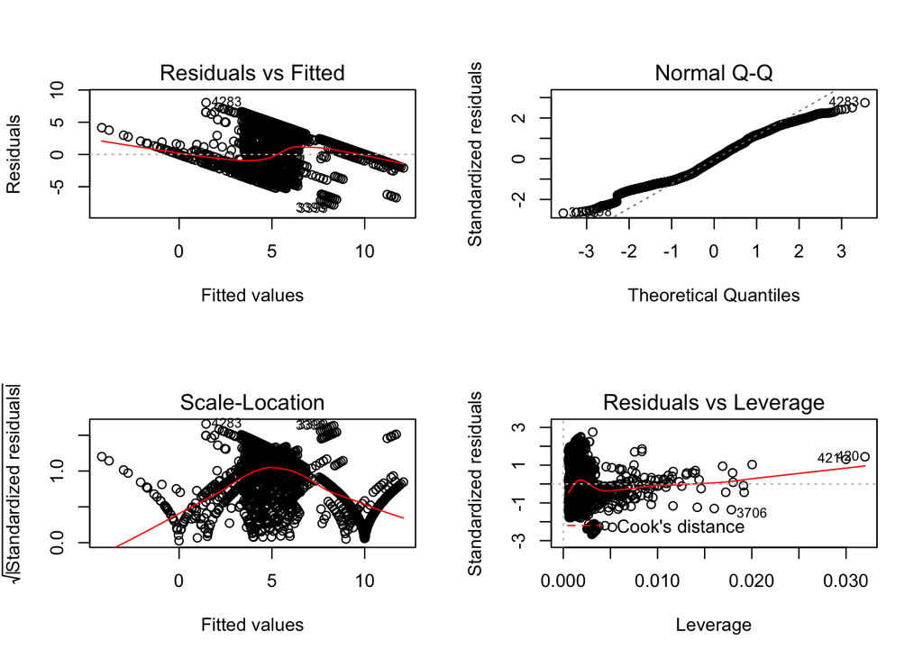

```r
par(mfrow=c(2,2))
plot(model1)
```

```r
par(mfrow=c(1,1))
```

# Sources

- Oil data from : Ross 2001.
- Carolina Johnson, Jeffrey B. Arnold http://staff.washington.edu/csjohns/503/lab6.r